# Chapter 4 Specific Factors and Income Distribution

# Chapter Organization

- Introduction
- The Specific Factors Model
- International Trade in the Specific Factors Model
- Income Distribution and the Gains from Trade
- Political Economy of Trade: A Preliminary View
- International Labor Mobility
- Summary

# Introduction

- If trade is so good for the economy, why is there such opposition?
- Two main reasons why international trade has strong effects on the distribution of income within a country:
  - Resources cannot move immediately or costlessly from one industry to another.
  - Industries differ in the factors of production they demand.

# The Specific Factors Model

# The Specific Factors Model

- The **specific factors model** allows trade to affect income distribution.
- Assumptions of the model:
  - Two goods, cloth and food.
  - Three factors of production: labor (L), capital (K) and land (T for terrain).
  - Perfect competition prevails in all markets.

# The Specific Factors Model

- Cloth produced using capital and labor (but not land).
- Food produced using land and labor (but not capital).
- Labor is a mobile factor that can move between sectors.
- Land and capital are both specific factors used only in the production of one good.

# The Specific Factors Model

- How much of each good does the economy produce?
- The production function for cloth gives the quantity of cloth that can be produced given any input of capital and labor: $Q_C = Q_C (K, L_C)$
  - $Q_C$ is the output of cloth
  - *K* is the capital stock
  - $L_C$ is the labor force employed in cloth

# The Specific Factors Model

- The production function for food gives the quantity of food that can be produced given any input of land and labor: $Q_F = Q_F (T, L_F)$
  - $Q_F$ is the output of food
  - *T* is the supply of land
  - $L_F$ is the labor force employed in food

# Production Possibilities

- How does the economy’s mix of output change as labor is shifted from one sector to the other?
- When labor moves from food to cloth, food production falls while output of cloth rises.
- Figure 4-1 illustrates the production function for cloth.

# The PF for Cloth

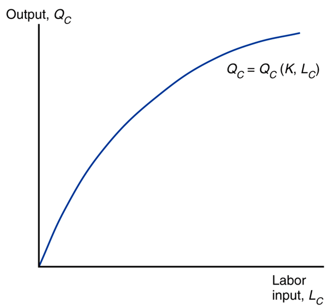

# Production Possibilities

- The shape of the production function reflects the law of **diminishing marginal returns**.
  - Adding one worker to the production process (without increasing the amount of capital) means that each worker has less capital to work with.
  - Therefore, each additional unit of labor adds less output than the last.
- Figure 4-2 shows the **marginal product of labor**, which is the increase in output that corresponds to an extra unit of labor.

# The MP of Labor

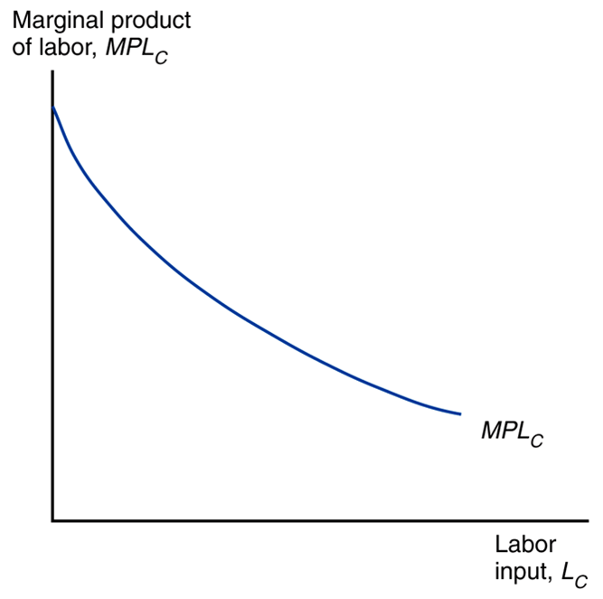

# Production Possibilities

- For the economy as a whole, the total labor employed in cloth and food must equal the total labor supply: $L_C + L_F = L$
- Use these equations to derive the **production possibilities frontier** of the economy.

# Production Possibilities

- Use a four-quadrant diagram to construct production possibilities frontier in Figure 4-3.
  - Lower left quadrant indicates the allocation of labor.
  - Lower right quadrant shows the production function for cloth from Figure 4-1.
  - Upper left quadrant shows the corresponding production function for food.
  - Upper right quadrant indicates the combinations of cloth and food that can be produced.

# The PPF in the Specific Factors Model

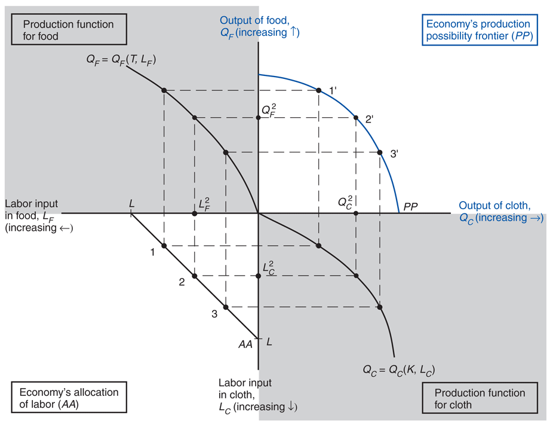

# Production Possibilities

- Why is the production possibilities frontier curved?
  - Diminishing returns to labor in each sector cause the opportunity cost to rise when an economy produces more of a good.
  - Opportunity cost of cloth in terms of food is the slope of the production possibilities frontier – the slope becomes steeper as an economy produces more cloth.

# Production Possibilities

- Opportunity cost of producing one more yard of cloth is $MPL_F/MPL_C$ pounds of food.
  - To produce one more yard of cloth, you need 1/$MPL_C$ hours of labor.
  - To free up one hour of labor, you must reduce output of food by $MPL_F$ pounds.
  - To produce less food and more cloth, employ less in food and more in cloth.
    - The marginal product of labor in food rises and the marginal product of labor in cloth falls, so $MPL_F/MPL_C$ rises.

# Prices, Wages, and Labor Allocation

- How much labor is employed in each sector?
  - Need to look at supply and demand in the labor market.
- Demand for labor:
  - In each sector, employers will maximize profits by demanding labor up to the point where the value produced by an additional hour equals the marginal cost of employing a worker for that hour.

# Prices, Wages, and Labor Allocation

- The demand curve for labor in the cloth sector: $MPL_C \times P_C = w$
  - The wage equals the value of the marginal product of labor in manufacturing.
- The demand curve for labor in the food sector: $MPL_F \times P_F = w$
  - The wage equals the value of the marginal product of labor in food.

# Prices, Wages, and Labor Allocation

- Figure 4-4 represents labor demand in the two sectors.
- The demand for labor in the cloth sector is $MPL_C$ from Figure 4-2 multiplied by $P_C$.
- The demand for labor in the food sector is measured from the right.
- The horizontal axis represents the total labor supply *L*.

# Prices, Wages, and Labor Allocation

- The two sectors must pay the same wage because labor can move between sectors.
- If the wage were higher in the cloth sector, workers would move from making food to making cloth until the wages become equal.
  - Or if the wage were higher in the food sector, workers would move in the other direction.
- Where the labor demand curves intersect gives the equilibrium wage and allocation of labor between the two sectors.

# The Allocation of Labor

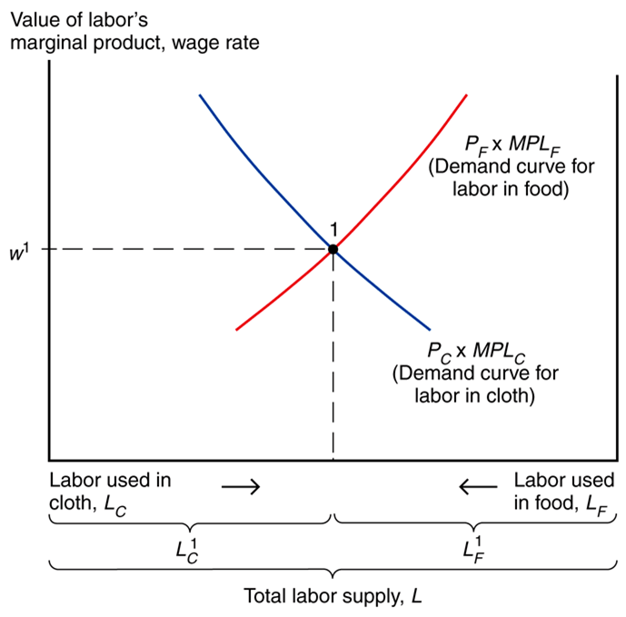

# Prices, Wages, and Labor Allocation

- At the production point, the production possibility frontier must be tangent to a line whose slope is minus the price of cloth divided by that of food.
- Relationship between relative prices and output: $-\frac{MPL_F}{MPL_C} = -\frac{P_C}{P_F}$

# Production in the Specific Factors Model

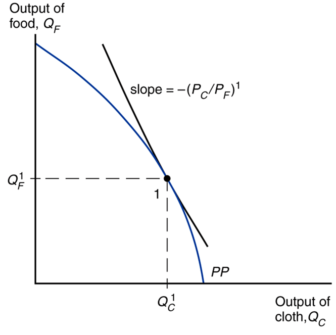

# Prices, Wages, and Labor Allocation

- What happens to the allocation of labor and the distribution of income when the prices of food and cloth change?
- Two cases:
  - An equal proportional change in prices
  - A change in relative prices

# Prices, Wages, and Labor Allocation

- When both prices change in the same proportion, no real changes occur.
  - The wage rate (*w*) rises in the same proportion as the prices, so real wages (i.e., the ratios of the wage rate to the prices of goods) are unaffected.
  - The real incomes of capital owners and landowners also remain the same.

# An Equal-Proportional Increase

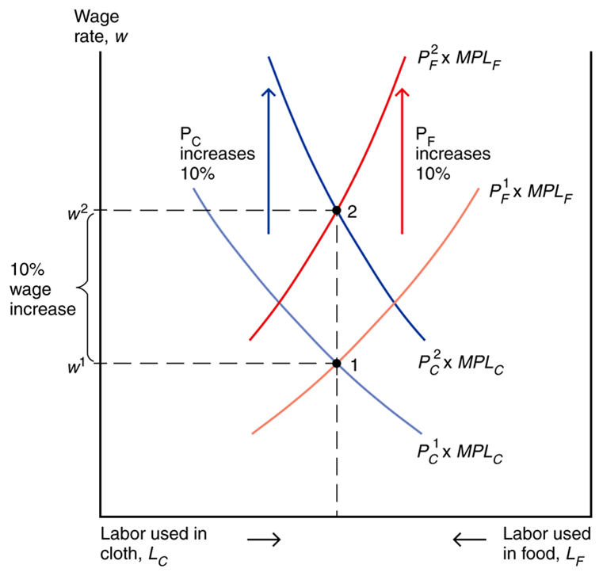

# Prices, Wages, and Labor Allocation

- When only $P_C$ rises, labor shifts from the food sector to the cloth sector and the output of cloth rises while that of food falls.
- The wage rate (*w*) does not rise as much as $P_C$ since cloth employment increases and thus the marginal product of labor in that sector falls.

# A Rise in the Price of Cloth

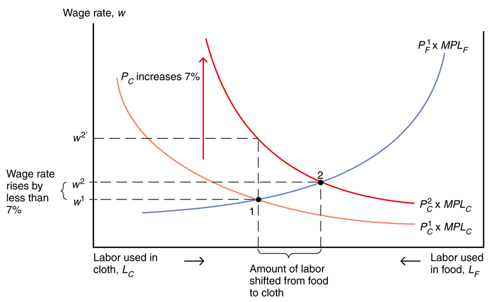

# Response of Output to a Change in the RP of Cloth

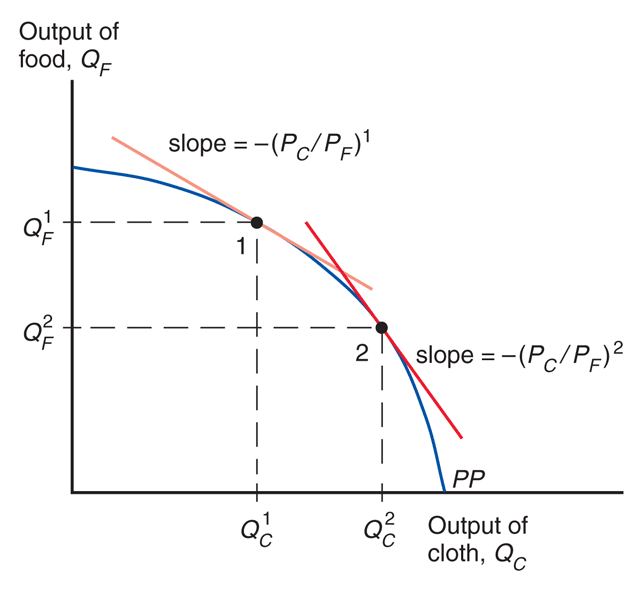

# Determination of RP

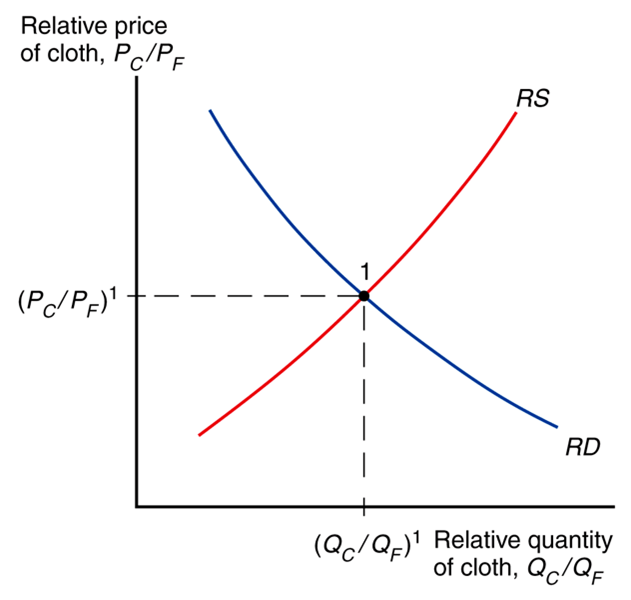

# Prices, Wages, and Labor Allocation

# Prices, Wages, and Labor Allocation

- Owners of capital are definitely better off.
- Landowners are definitely worse off.
- Workers: cannot say whether workers are better or worse off:
  - Depends on the relative importance of cloth and food in workers’ consumption.

# International Trade in the Specific Factors Model

# International Trade in the Specific Factors Model

- Trade and Relative Prices
  - The relative price of cloth prior to trade is determined by the intersection of the economy’s relative supply of cloth and its relative demand.
  - Free trade relative price of cloth is determined by the intersection of world relative supply of cloth and world relative demand.
  - Opening up to trade increases the relative price of cloth in an economy whose relative supply of cloth is larger than for the world as a whole.

# Trade and RP

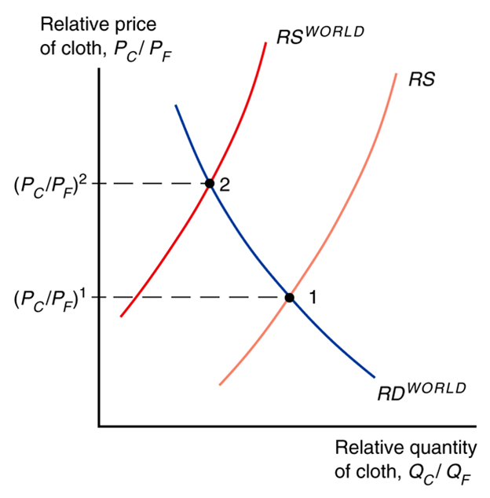

# International Trade in the Specific Factors Model

- Gains from Trade
  - Without trade, the economy’s output of a good must equal its consumption.
  - International trade allows the mix of cloth and food consumed to differ from the mix produced.
  - The country cannot spend more than it earns: $P_C \times D_C + P_F \times D_F = P_C \times Q_C +P_F \times Q_F$

# International Trade in the Specific Factors Model

- The economy as a whole gains from trade.
  - It imports an amount of food equal to the relative price of cloth times the amount of cloth exported: $D_F - Q_F = \left(\frac{P_C}{P_F} \right) \times (Q_C – D_C)$
  - It is able to afford amounts of cloth and food that the country is not able to produce itself.
  - The budget constraint with trade lies above the production possibilities frontier in Figure 4-11.

# The BC and Gains from Trade

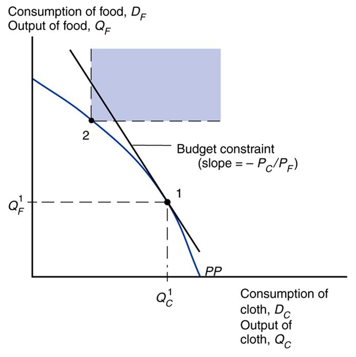

# Income Distribution and the Gains from Trade

# Income Distribution and the Gains from Trade

- International trade shifts the relative price of cloth to food, so factor prices change.
- Trade benefits the factor that is specific to the export sector of each country, but hurts the factor that is specific to the import-competing sectors.
- Trade has ambiguous effects on mobile factors.

# Income Distribution and the Gains from Trade

- Trade benefits a country by expanding choices.
  - Possible to redistribute income so that everyone gains from trade.
  - Those who gain from trade could compensate those who lose and still be better off themselves.
  - That everyone could gain from trade does not mean that they actually do – redistribution usually hard to implement.

# The Political Economy of Trade: A Preliminary View

# The Political Economy of Trade: A Preliminary View

- Trade often produces losers as well as winners.
- Optimal trade policy must weigh one group’s gain against another’s loss.
  - Some groups may need special treatment because they are already relatively poor (e.g., shoe and garment workers in the United States).
- Most economists strongly favor free trade.

# The Political Economy of Trade: A Preliminary View

- Income Distribution and Trade Politics
  - Typically, those who gain from trade are a much less concentrated, informed, and organized group than those who lose.
    - Example: Consumers and producers in the U.S. sugar industry, respectively
  - Governments usually provide a “safety net” of income support to cushion the losses to groups hurt by trade (or other changes).

# Trade and Unemployment

- Trade shifts jobs from import-competing to export sector.
  - Process not instantaneous – some workers will be unemployed as they look for new jobs.
- How much unemployment can be traced back to trade?
  - From 1996 to 2008, only about 2.5% of involuntary displacements stemmed from import competition or plants moved overseas.

# Trade and Unemployment

- Figure 4-12 shows that there is no obvious correlation between unemployment rate and imports relative to GDP for the U.S.
  - Unemployment is primarily a macroeconomic problem that rises during recessions.
  - The best way to reduce unemployment is by adopting macroeconomic policies to help the economy recover, not by adopting trade protection.

# Unemployment and Import Penetration in the U.S.

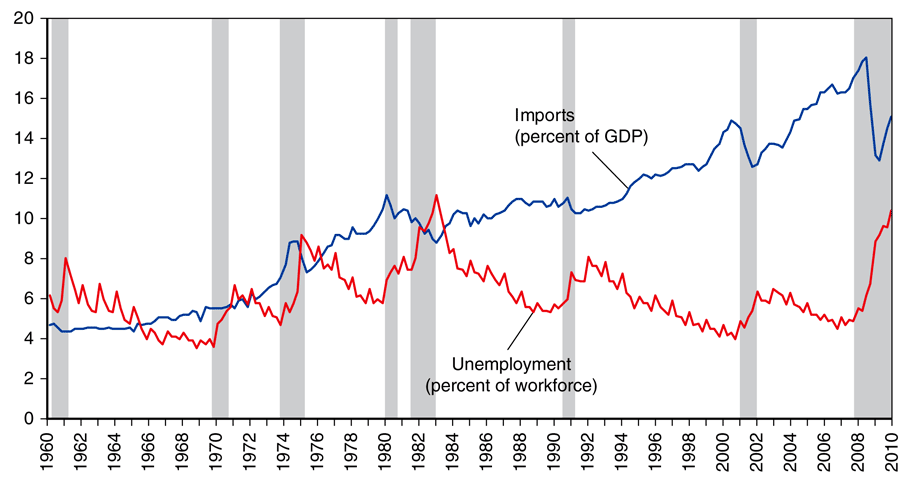

# Movements in Factors of Production

- Movements in factors of production include
  - labor migration
  - the transfer of financial assets through international borrowing and lending
  - transactions of multinational corporations involving direct ownership of foreign firms
- Like movements of goods and services (trade), movements of factors of production are politically sensitive and are often restricted.

# International Labor Mobility

# International Labor Mobility

- Why does labor migrate and what effects does labor migration cause?
- Workers migrate to wherever wages are highest.
- Consider movement of labor across countries instead of across sectors.
- Suppose two countries produce one non-traded good (food) using two factors of production:
  - Land cannot move across countries but labor can.

# International Labor Mobility

- Figure 4-13 finds the equilibrium wage and labor allocation with migration across countries.
  - Similar to how Figure 4-4 determined the equilibrium allocation of labor between sectors.
- Start with $OL^1$ workers in Home earning a lower real wage (point C) than the $L^1O^*$ workers in Foreign (point B).
  - Lower wage due to less land per worker (lower productivity).
- Workers in the home country want to migrate to the foreign country where they can earn more.

# International Labor Mobility

- If no obstacles to labor migration exist, workers move from Home to Foreign until the purchasing power of wages is equal across countries (point A), with $OL^2$ workers in Home and $L^2O^*$ workers in Foreign.
  - Emigration from Home decreases the supply of labor and raises real wage of the workers who remain there.
    - Workers who start in the Home country earn more due to emigration regardless if they are among those who leave.
  - Immigration into Foreign increases the supply of labor and decreases the real wage there.
- Wages do not actually equalize, due to barriers to migration such as policies restricting immigration and natural reluctance to move.

# Causes and Effects of International Labor Mobility

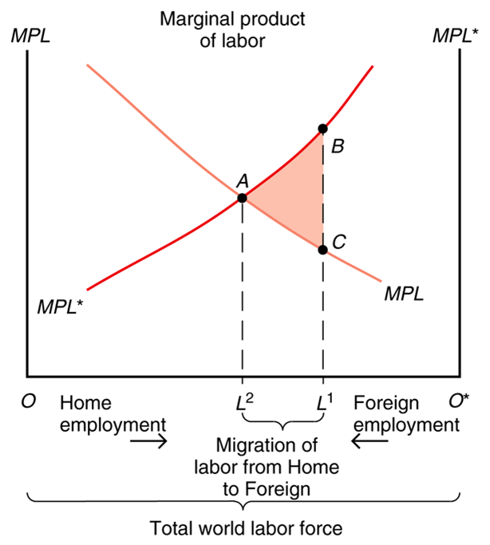

# International Labor Mobility

- Labor migration increases world output.
  - The value of foreign output rises by the area under its $MPL^*$ curve from $L^1$ to $L^2$
  - The value of domestic output falls by the area under its *MPL* curve from $L^2$ to $L^1$
  - World output rises because labor moves to where it is more productive (where wages are higher).
  - The value of world output is maximized when the marginal productivity of labor is the same across countries.

# International Labor Mobility

- Workers initially in Home benefit while workers in Foreign are hurt by inflows of other workers.
  - Landowners in Foreign gain from the inflow of workers decreasing real wages and increasing output.
  - Landowners in Home are hurt by the outflow of workers increasing real wages and decreasing output.

# International Labor Mobility

- Does migration lead to the wage changes predicted?
- Table 4-1 shows that real wages in 1870 were much higher in destination countries than in origin countries.
- Up until the eve of World War I in 1913, wages rose faster in origin countries than in destination countries (except Canada).
- Migration moved the world toward more equalized wages.

# Table 4-1

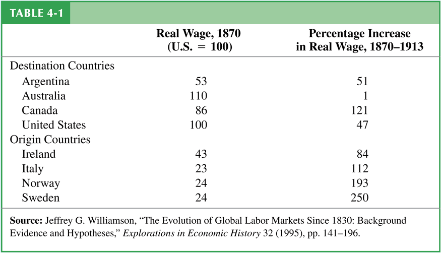

# International Labor Mobility

- In the early 20th century, share of immigrants in the U.S. increased dramatically.
  - Vast immigration from Eastern and Southern Europe.
- Tight restrictions on immigration imposed in the 1920s.
  - Immigrants were a minor force in the U.S. by the 1960s.
- New wave of immigration began around 1970.
  - Mostly from Latin America and Asia.
- As of 2006, 15.3% of the U.S. labor force foreign-born.

# Immigrants as a Percentage of the U.S. Population

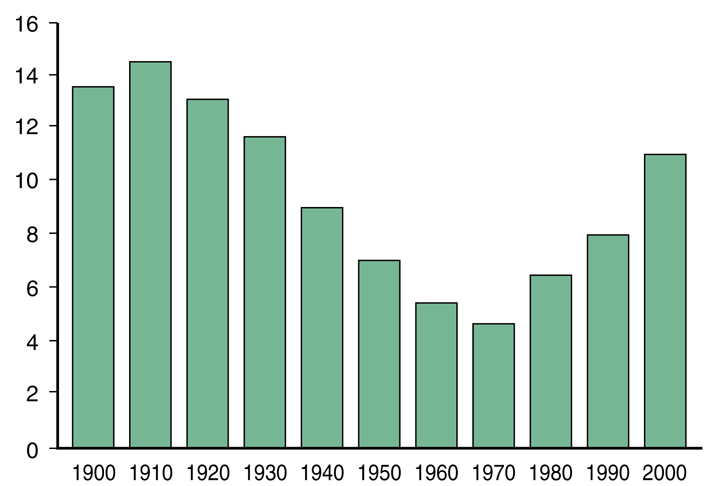

# Immigration and the U.S. Economy

- The largest increase in recent immigration occurred among workers with the lowest education levels, making less educated workers more abundant.
  - possibly reduced wages for native-born workers with low education levels while raising wages for the more educated
  - widening wage gap between less educated workers and highly educated workers.

# Summary

# Summary

1. International trade often has strong effects on the distribution of income within countries – produces losers as well as winners.
2. Income distribution effects arise for two reasons:
   - Factors of production cannot move costlessly and quickly from one industry to another.
   - Changes in an economy’s output mix have differential effects on the demand for different factors of production.

# Summary

3. International trade affects the distribution of income in the specific factors model.
   - Factors specific to export sectors in each country gain from trade, while factors specific to import-competing sectors lose.
   - Mobile factors that can work in either sector may either gain or lose.

# Summary

4. Trade nonetheless produces overall gains in the sense that those who gain could in principle compensate those who lose while still remaining better off than before.
5. Most economists would prefer to address the problem of income distribution directly, rather than by restricting trade.
6. Those hurt by trade are often better organized than those who gain, causing trade restrictions to be adopted.

# Summary

7. Labor migrates to countries with higher labor productivity and higher real wages, where labor is scarce.
   - Real wages fall due to immigration and rise due to emigration.
   - World output increases.
8. Real wages across countries are far from equal due to differences in technology and due to immigration barriers.